# ICCS datafiles 1999/2009/2016/2022

# Files available

Selected countries and years (cycle) to analyse

```
[1] "Countries selected and year participation in ICCS:"
```

[output not shown]

# Description of variables

## Construct: Attitudes toward equal rights for immigrants

### Responses Cycle 1 - CivED1999

[1] “Items: BS4H1, BS4H2, BS4H3, BS4H4, BS4H5”

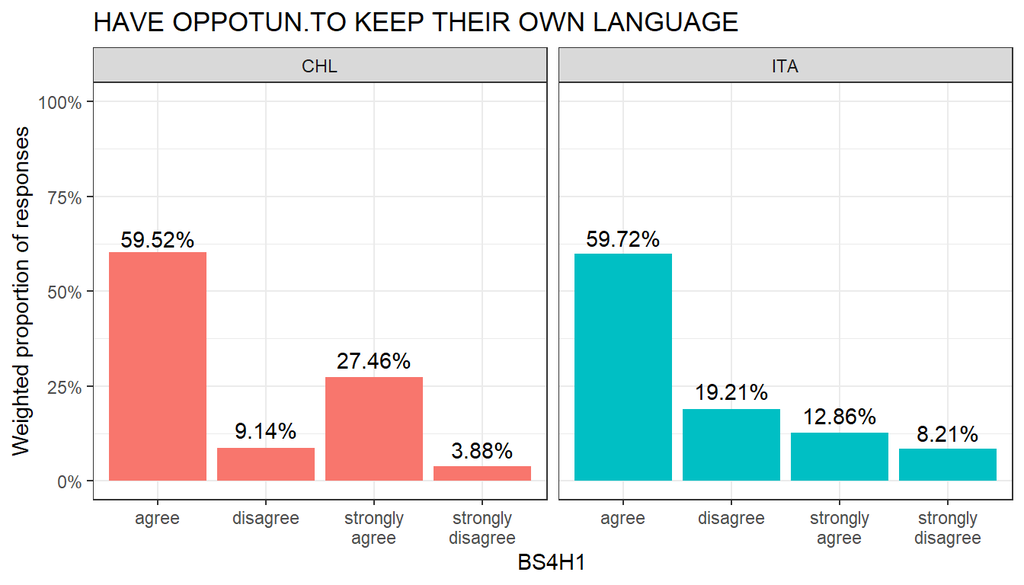

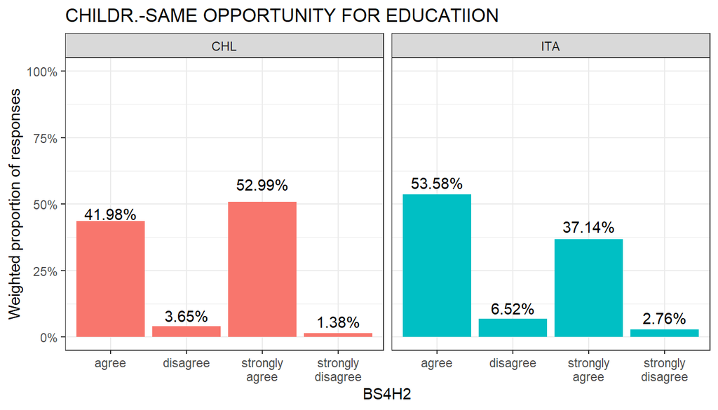

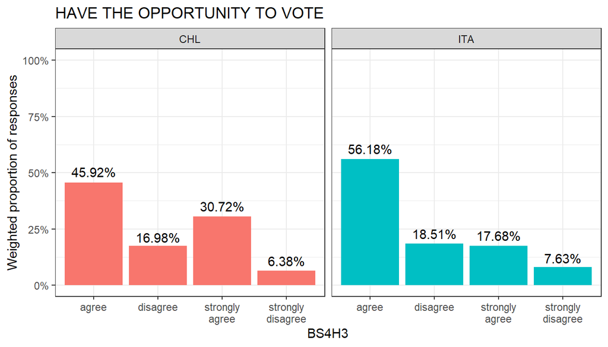

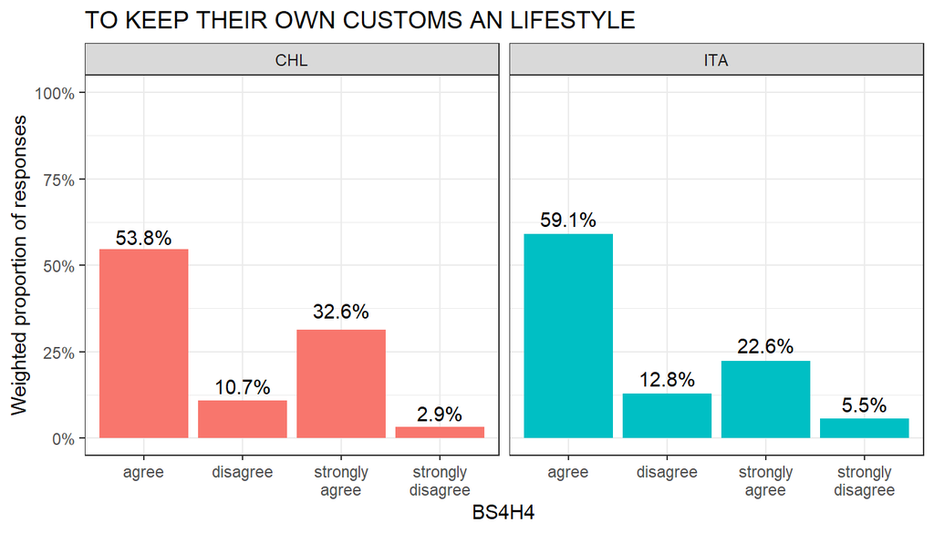

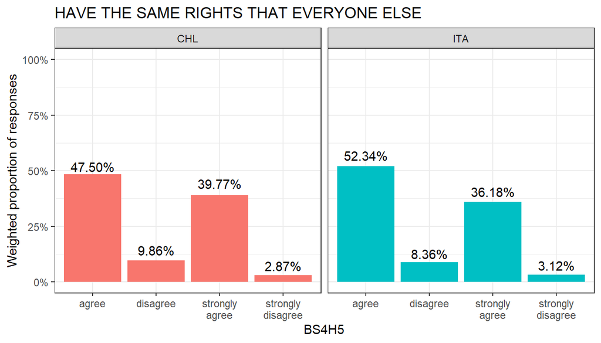

### Responses Cycle 2 - ICCS2009

[1] “Items: IS2P26A, IS2P26B, IS2P26C, IS2P26D, IS2P26E”

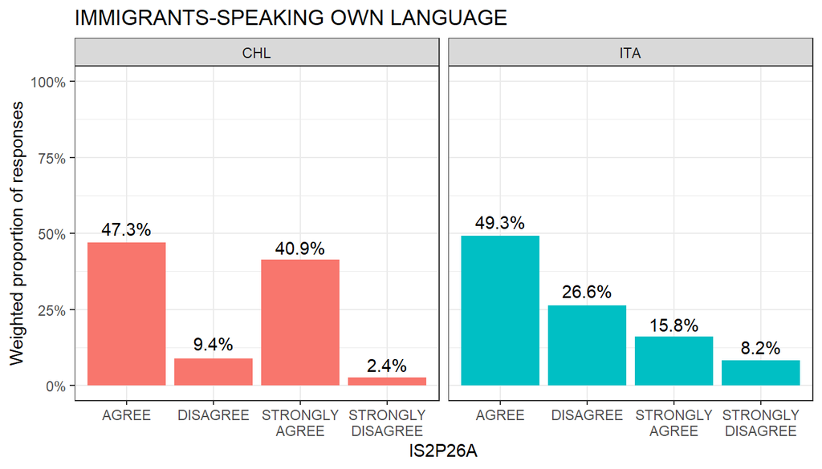

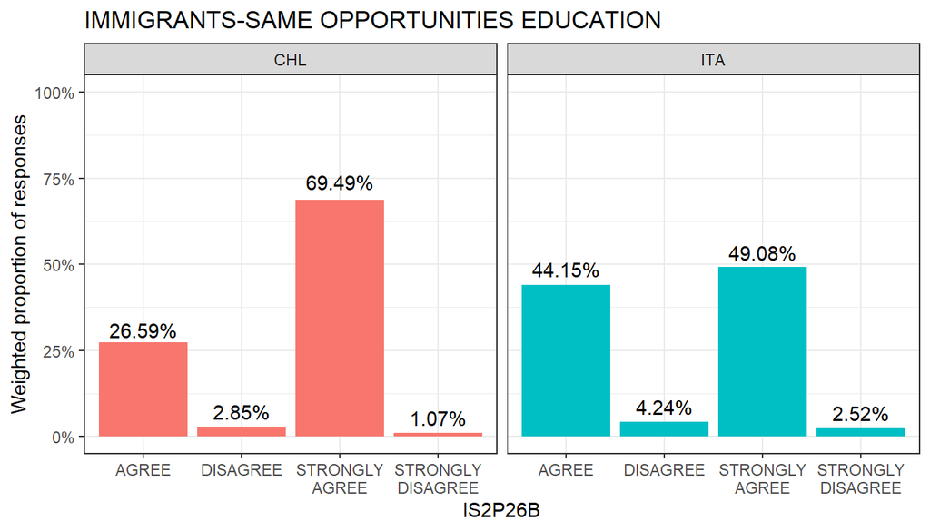

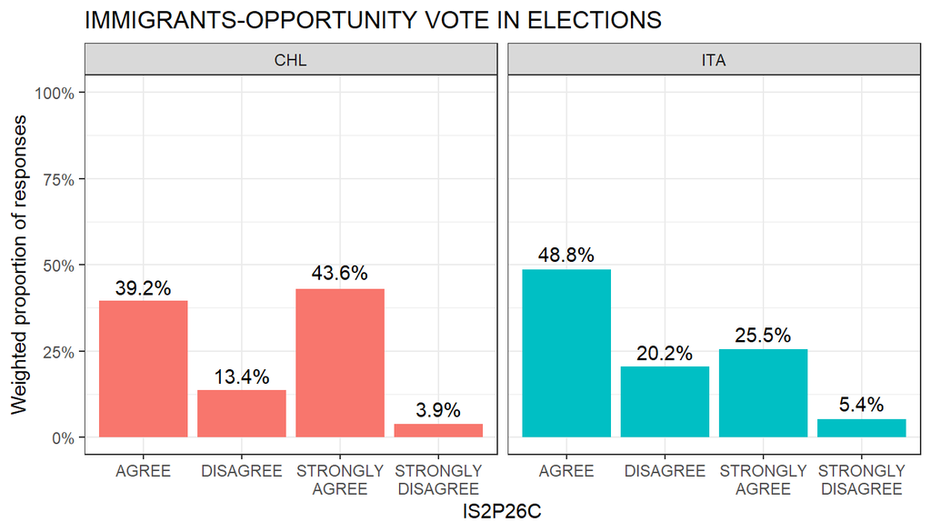

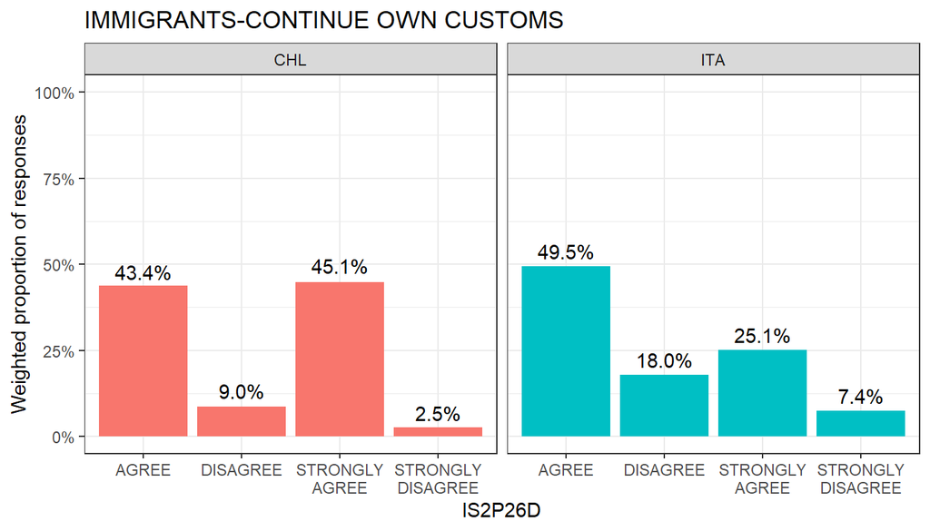

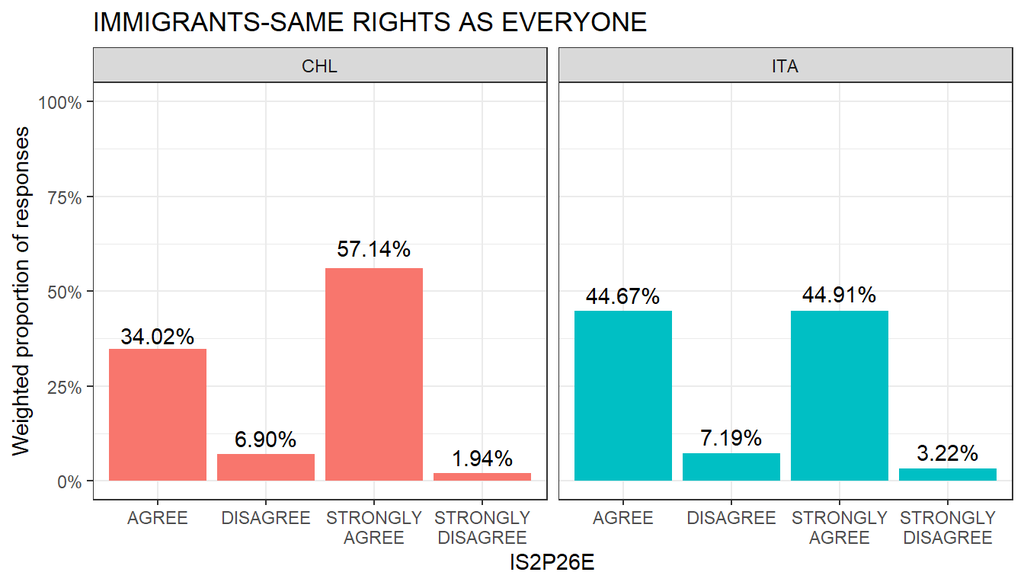

### Responses Cycle 3 - ICCS2016

[1] “Items: ES3G04A, ES3G04B, ES3G04C, ES3G04D, ES3G04E”

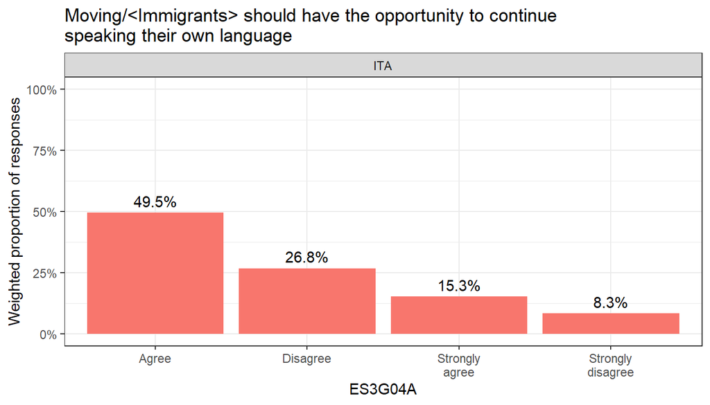

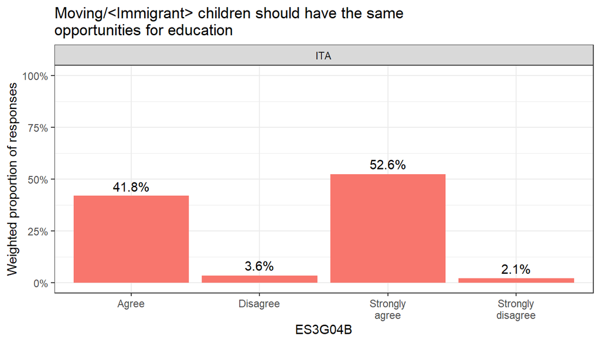

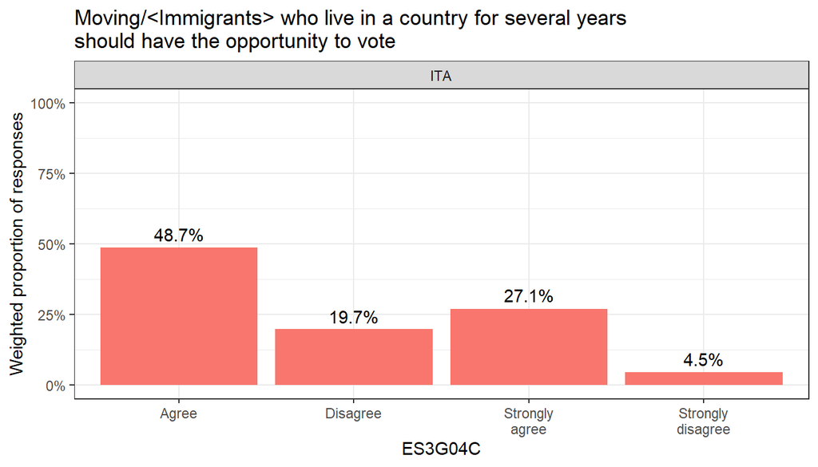

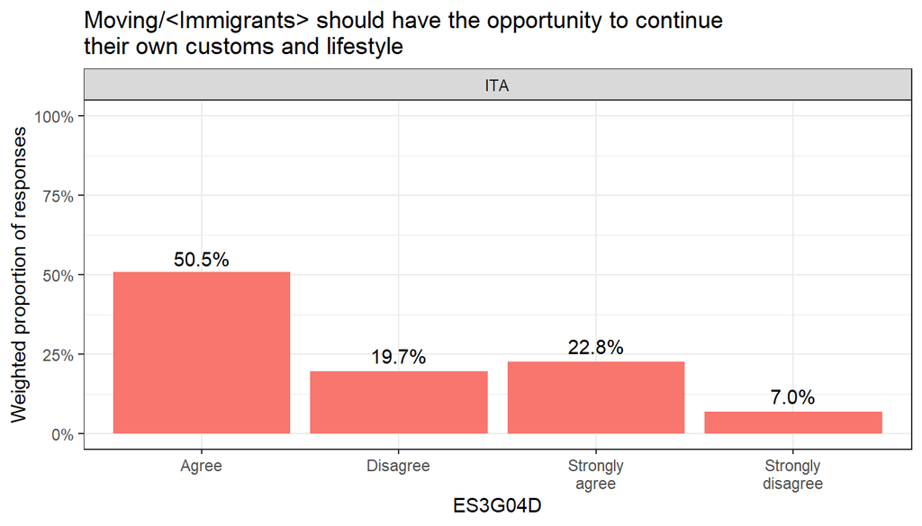

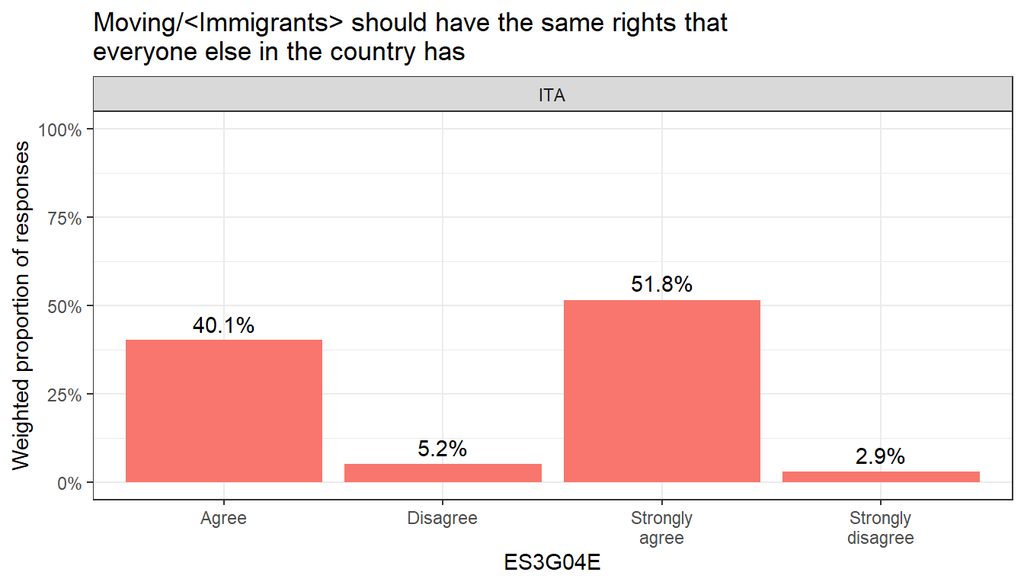

## Construct: Attitudes toward gender equality

### Responses Cycle 1 - CivED1999

[1] “Items: BS4G4, BS4G6, BS4G9, BS4G11, BS4G13”

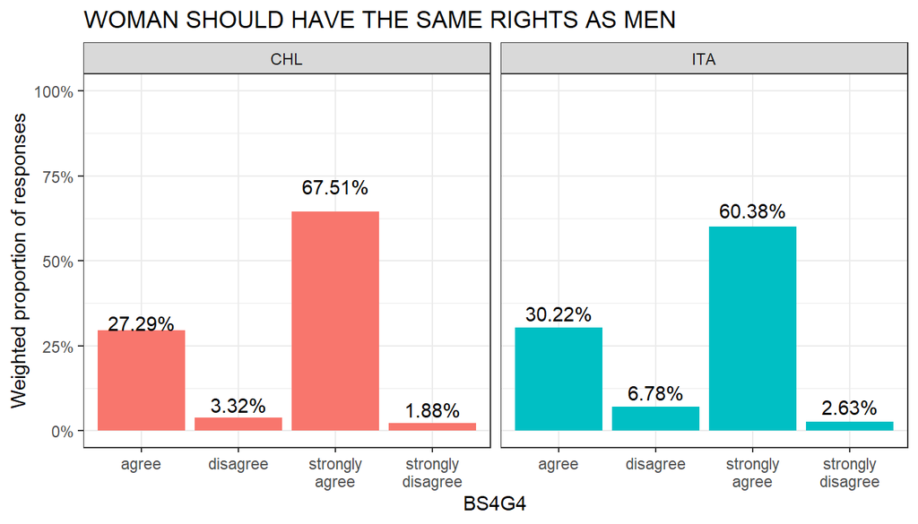

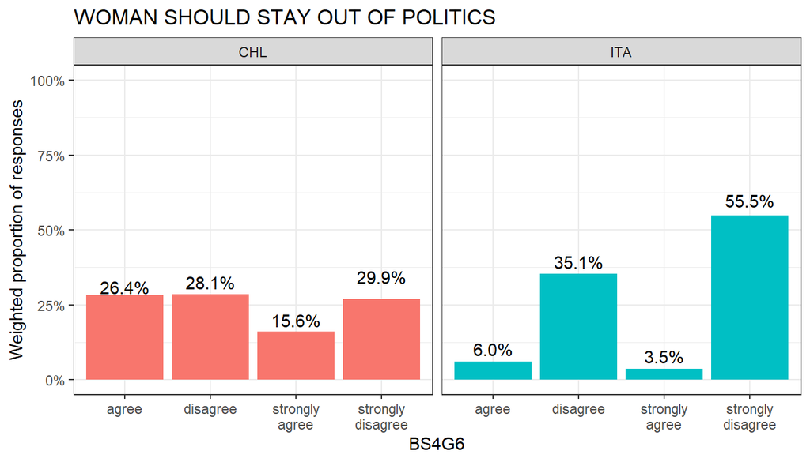

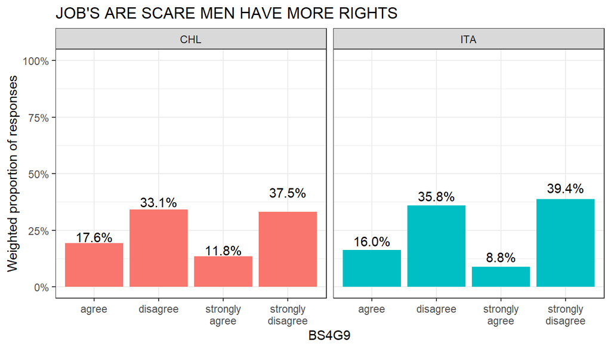

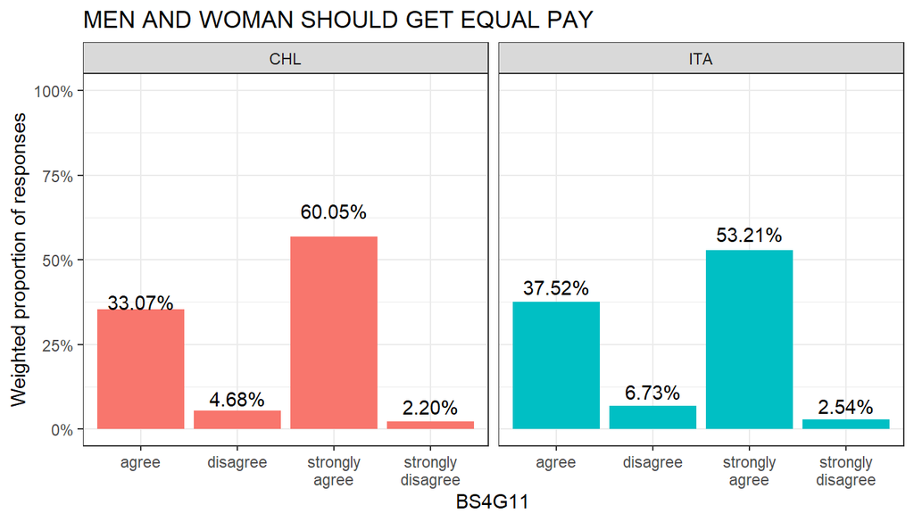

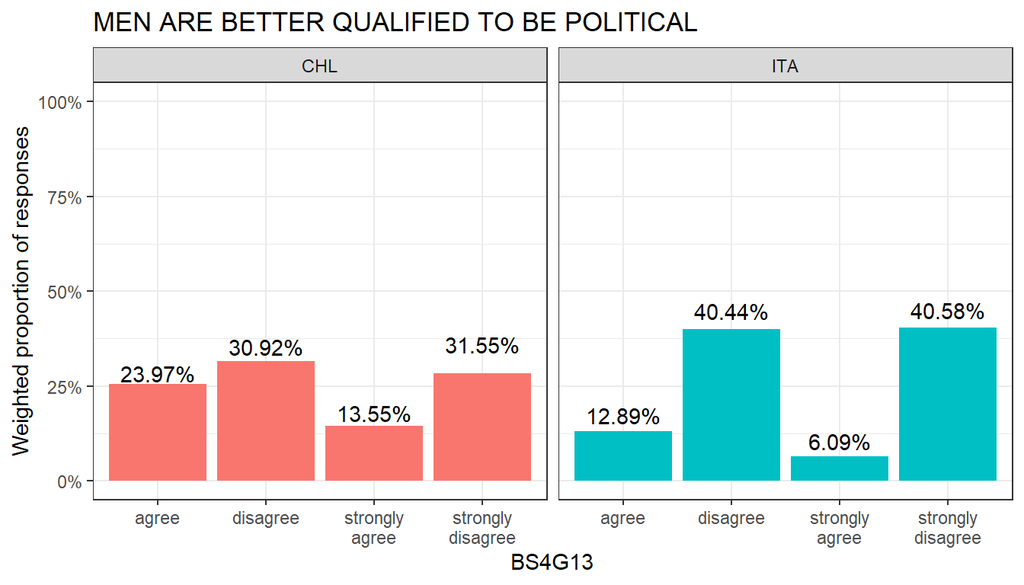

### Responses Cycle 2 - ICCS2009

[1] “Items: IS2P24A, IS2P24B, IS2P24C, IS2P24D, IS2P24E, IS2P24F”

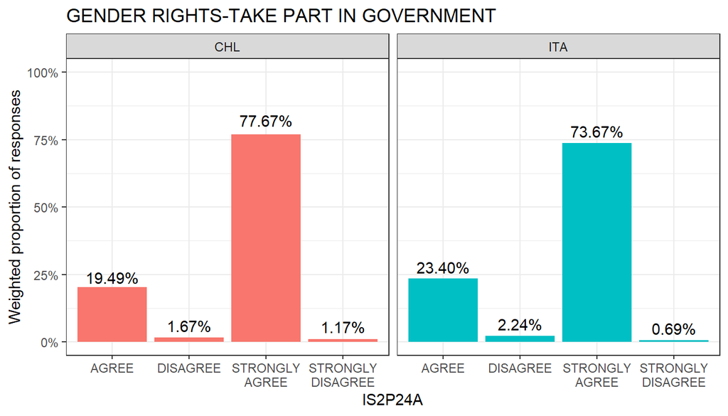

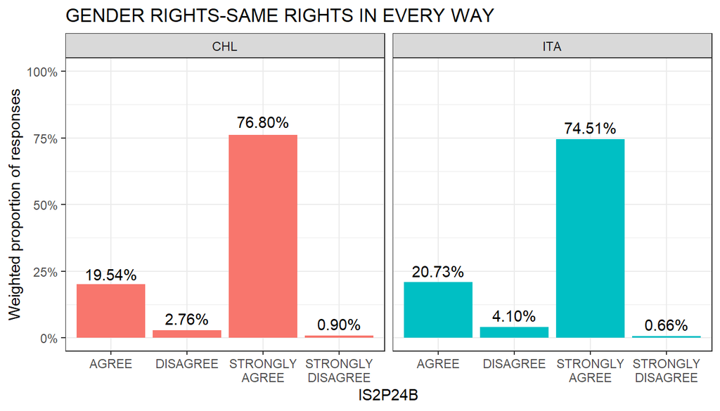

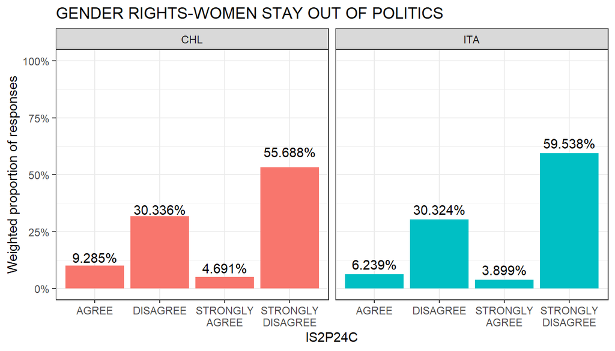

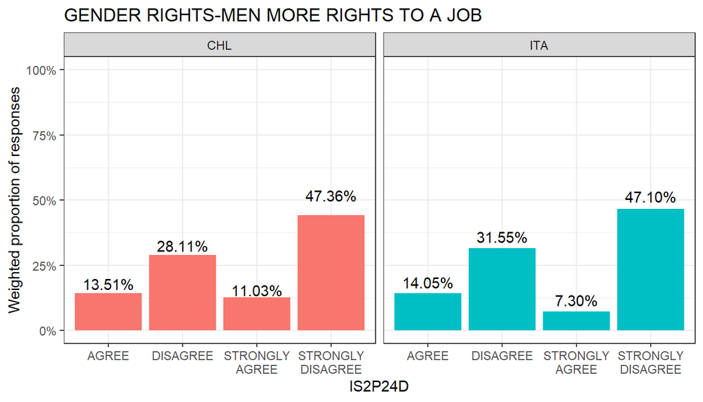

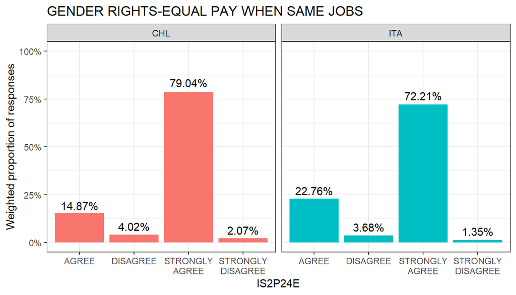

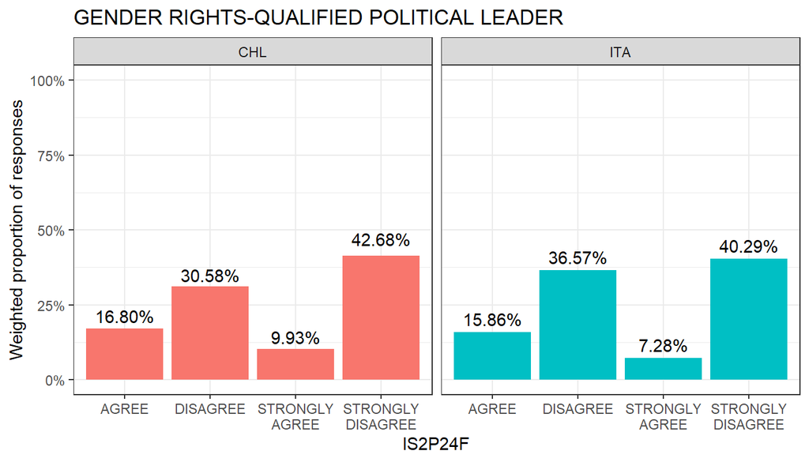